# R Notebook

Neil Yetz & Gemma Wallace

# Load Libraries

```r
library(tidyverse)
library(olsrr)
library(psych)
```

# Read in dataset

```r
slp <- read_csv("slpdata.csv")
```

# Describe variables

```r
describe(slp)
```

|  | vars | n | mean | sd | median | trimmed | mad | min | max | range | skew | kurtosis | se |
| --- | --- | --- | --- | --- | --- | --- | --- | --- | --- | --- | --- | --- | --- |
| cond | 1 | 600 | 2.0000000 | 0.8171778 | 2.000 | 2.0000000 | 1.482600 | 1.00 | 3.00 | 2.00 | 0.00000000 | -1.50499583 | 0.03336115 |
| prior | 2 | 600 | 0.7233333 | 0.4477235 | 1.000 | 0.7791667 | 0.000000 | 0.00 | 1.00 | 1.00 | -0.99597685 | -1.00970463 | 0.01827823 |
| age | 3 | 600 | 44.9400000 | 12.8655524 | 45.200 | 45.1245833 | 16.456860 | 20.00 | 67.80 | 47.80 | -0.09745994 | -1.13828406 | 0.52523398 |
| anxiety | 4 | 600 | 3.8824500 | 0.9047863 | 3.860 | 3.8924167 | 0.926625 | 1.05 | 6.84 | 5.79 | -0.07223473 | -0.06024914 | 0.03693775 |
| hygiene | 5 | 600 | 5.9941333 | 1.5738213 | 6.050 | 6.0371458 | 1.571556 | 1.68 | 9.74 | 8.06 | -0.23454564 | -0.28674288 | 0.06425098 |
| support | 6 | 600 | 3.0410500 | 0.6810659 | 2.960 | 3.0225833 | 0.726474 | 1.09 | 4.91 | 3.82 | 0.21271474 | -0.50719406 | 0.02780440 |
| sleep | 7 | 600 | 68.8766667 | 12.1397589 | 69.000 | 69.0854167 | 11.860800 | 34.00 | 99.00 | 65.00 | -0.15727289 | -0.17457777 | 0.49560358 |
| lifesat | 8 | 600 | 4.0563500 | 0.9155668 | 4.055 | 4.0398750 | 0.956277 | 1.68 | 6.61 | 4.93 | 0.13308413 | -0.22525077 | 0.03737786 |
| sex | 9 | 600 | 1.4116667 | 0.4925460 | 1.000 | 1.3895833 | 0.000000 | 1.00 | 2.00 | 1.00 | 0.35808274 | -1.87489324 | 0.02010811 |
| id | 10 | 600 | 300.5000000 | 173.3493582 | 300.500 | 300.5000000 | 222.390000 | 1.00 | 600.00 | 599.00 | 0.00000000 | -1.20600164 | 7.07695792 |

categorical vars = cond, prior, & sex

# Part 1: Using dummy coding, use treatment condition, sex, and their interaction to predict sleep hygiene.

## Specify dummy codes for categorical predictors

```r
#sex & condition
slp <- mutate(slp,
              sex = ifelse(sex == 1, 0, 1),
              sex.f = factor(sex, levels = c(0,1), labels = c("male", "female")))

slp <- mutate(slp,
              cond2 = ifelse(cond == 2, 1, 0),
              cond3 = ifelse(cond == 3, 1, 0))
```

## Run model

```r
m1 <- lm(hygiene ~ cond2 + cond3, data = slp)
ols_regress(m1)
```

```
##                         Model Summary
## --------------------------------------------------------------
## R                       0.630       RMSE                1.224
## R-Squared               0.397       Coef. Var          20.418
## Adj. R-Squared          0.395       MSE                 1.498
## Pred R-Squared          0.391       MAE                 0.973
## --------------------------------------------------------------
##  RMSE: Root Mean Square Error
##  MSE: Mean Square Error
##  MAE: Mean Absolute Error
##
##                                 ANOVA
## ----------------------------------------------------------------------
##                 Sum of
##                Squares         DF    Mean Square       F         Sig.
## ----------------------------------------------------------------------
## Regression     589.467          2        294.733    196.774    0.0000
## Residual       894.205        597          1.498
## Total         1483.671        599
## ----------------------------------------------------------------------
##
##                                  Parameter Estimates
## -------------------------------------------------------------------------------------
##       model     Beta    Std. Error    Std. Beta      t        Sig     lower    upper
## -------------------------------------------------------------------------------------
## (Intercept)    4.660         0.087                 53.853    0.000    4.490    4.830
##       cond2    1.627         0.122        0.488    13.293    0.000    1.386    1.867
##       cond3    2.374         0.122        0.712    19.399    0.000    2.134    2.615
## -------------------------------------------------------------------------------------
```

Interpretation of dummy coded model:

Intercept: The predicted sleep hygiene score when all x variables are zero, so participants in Condition 1.

cond2: the predicted difference in sleep hygiene score between particiants in condition 2 compared to condition 1.

cond3: the predicted difference in sleep hygiene score between particiants in condition 3 compared to condition 1.

## Run model with interaction

```r
m1 <- lm(hygiene ~ sex.f + cond2 + cond3 + sex.f*cond2 + sex.f*cond3, data = slp)
ols_regress(m1)
```

```
##                         Model Summary
## --------------------------------------------------------------
## R                       0.771       RMSE                1.007
## R-Squared               0.594       Coef. Var          16.801
## Adj. R-Squared          0.591       MSE                 1.014
## Pred R-Squared          0.585       MAE                 0.799
## --------------------------------------------------------------
##  RMSE: Root Mean Square Error
##  MSE: Mean Square Error
##  MAE: Mean Absolute Error
##
##                                 ANOVA
## ----------------------------------------------------------------------
##                 Sum of
##                Squares         DF    Mean Square       F         Sig.
## ----------------------------------------------------------------------
## Regression     881.213          5        176.243    173.768    0.0000
## Residual       602.459        594          1.014
## Total         1483.671        599
## ----------------------------------------------------------------------
##
##                                      Parameter Estimates
## ----------------------------------------------------------------------------------------------
##             model      Beta    Std. Error    Std. Beta      t        Sig      lower     upper
## ----------------------------------------------------------------------------------------------
##       (Intercept)     3.751         0.098                 38.346    0.000     3.559     3.943
##       sex.ffemale     1.935         0.143        0.418    13.562    0.000     1.655     2.215
##             cond2     2.084         0.132        0.625    15.813    0.000     1.825     2.343
##             cond3     2.962         0.135        0.888    21.933    0.000     2.697     3.227
## sex.ffemale:cond2    -0.643         0.207       -0.119    -3.113    0.002    -1.048    -0.237
## sex.ffemale:cond3    -1.160         0.203       -0.223    -5.710    0.000    -1.558    -0.761
## ----------------------------------------------------------------------------------------------
```

Interpretation of dummy coding model:

Intercept: The predicted sleep hygiene score when all x variables are zero, so males in Condition 1.

female: This variable is involved in an interaction, so it’s a simple slope. Specifically, it is the effect of female when both cond2 = 0 and cond3 = 0, so people in Condition 1. Therefore, it is the predicted difference in sleep hygiene between females and males in Condition 1. The slope is positive, meaning that females in Condition 1 tend to have better sleep hygiene than males in Condition 1. This is a sta-tistically significant difference (p-value is less than alpha).

cond2: This variable is involved in an interaction, so it is a simple slope. It is the effect of being in Condition 2 (compared to Condition 1) when female = 0, so among males. It is the predicted difference in sleep hygiene for males in Condition 2 compared to males in Condition 1. This is a statistically significant difference (p-value is less than alpha).

cond3: This variable is involved in an interaction, so it is a simple slope. It is the effect of being in Condition 3 (compared to Condition 1) when female = 0, so among males. It is the predicted difference in sleep hygiene for males in Condition 3 compared to males in Condition 1. This is a statistically significant difference (p-value is less than alpha).

female:cond2: The predicted differential effect of being in Condition 2 compared to Condition 1 for females compared to males. This is a statistically significant difference (p-value is less than alpha). The coefficient for cond2 presents the effect (i.e., benefit) of being in Condition 2 (compared to 1) for males. To get the effect for females, we take the effect for males (2.084) and add the female:cond2 interaction term (-.643). Therefore, the effect (i.e., benefit) of being in Condition 2 (compared to Condition 1) for females is 1.441.

female:cond3: The predicted differential effect of being in Condition 3 compared to Condition 1 for females compared to males. This is a statistically significant difference (p-value is less than alpha). The coefficient for cond3 presents the effect (i.e., benefit) of being in Condition 3 (compared to 1) for males. To get the effect for females, we take the effect for males (2.962) and add the female:cond3 interaction term (-1.160). Therefore, the effect (i.e., benefit) of being in Condition 3 (compared to Condition 1) for females is 1.802.

# Part 2: Redo this analysis using effect coding for treatment condition

## Specificy effect coding for categotical variables

“With this coding structure the same process is completed as that for dummy coding except the last group receives a −1 on all contrasts, thus only k −1 contrasts are used in this coding type (Wendorf, 2004).” (from Davis, 2010)

```r
slp <- mutate(slp,

              cond2 = ifelse(cond == 2, 1, 0),
              cond3 = ifelse(cond == 3, 1, 0),

              cond2 = ifelse(cond == 1, (-1), cond2),
              cond3 = ifelse(cond == 1, (-1), cond3),

              cond.f = factor(cond, levels = c(1,2,3), labels = c("self help", "group-based", "group + partner"))) #need this label specifier here?
```

## Run model without interaction first

```r
m2 <- lm(hygiene ~ cond2 + cond3, data = slp)
ols_regress(m2)
```

```
##                         Model Summary
## --------------------------------------------------------------
## R                       0.630       RMSE                1.224
## R-Squared               0.397       Coef. Var          20.418
## Adj. R-Squared          0.395       MSE                 1.498
## Pred R-Squared          0.391       MAE                 0.973
## --------------------------------------------------------------
##  RMSE: Root Mean Square Error
##  MSE: Mean Square Error
##  MAE: Mean Absolute Error
##
##                                 ANOVA
## ----------------------------------------------------------------------
##                 Sum of
##                Squares         DF    Mean Square       F         Sig.
## ----------------------------------------------------------------------
## Regression     589.467          2        294.733    196.774    0.0000
## Residual       894.205        597          1.498
## Total         1483.671        599
## ----------------------------------------------------------------------
##
##                                  Parameter Estimates
## --------------------------------------------------------------------------------------
##       model     Beta    Std. Error    Std. Beta       t        Sig     lower    upper
## --------------------------------------------------------------------------------------
## (Intercept)    5.994         0.050                 119.969    0.000    5.896    6.092
##       cond2    0.293         0.071        0.152      4.149    0.000    0.154    0.432
##       cond3    1.041         0.071        0.540     14.726    0.000    0.902    1.179
## --------------------------------------------------------------------------------------
```

Interpretation of effect coding model:

Effects coding allows us to examine mean differences between two groups. In effects coding, the slope estimates are simply the difference between the mean of the group coded as 1 and the grand mean of all the groups.

Intercept: In effect coding, the intercept is the grand mean of sleep hygiene across all the three treatment groups

cond2: the predicted difference in sleep hygiene score between particiants in condition 2 compared to the mean of all three treatment conditions.

cond3: the predicted difference in sleep hygiene score between particiants in condition 3 compared to the mean of all three treatment conditions.

## Run model with interaction

```r
m2 <- lm(hygiene ~ sex.f + cond2 + cond3 + sex.f*cond2 + sex.f*cond3, data = slp)
ols_regress(m2)
```

```
##                         Model Summary
## --------------------------------------------------------------
## R                       0.771       RMSE                1.007
## R-Squared               0.594       Coef. Var          16.801
## Adj. R-Squared          0.591       MSE                 1.014
## Pred R-Squared          0.585       MAE                 0.799
## --------------------------------------------------------------
##  RMSE: Root Mean Square Error
##  MSE: Mean Square Error
##  MAE: Mean Absolute Error
##
##                                 ANOVA
## ----------------------------------------------------------------------
##                 Sum of
##                Squares         DF    Mean Square       F         Sig.
## ----------------------------------------------------------------------
## Regression     881.213          5        176.243    173.768    0.0000
## Residual       602.459        594          1.014
## Total         1483.671        599
## ----------------------------------------------------------------------
##
##                                       Parameter Estimates
## -----------------------------------------------------------------------------------------------
##             model      Beta    Std. Error    Std. Beta       t        Sig      lower     upper
## -----------------------------------------------------------------------------------------------
##       (Intercept)     5.433         0.054                 101.005    0.000     5.327     5.539
##       sex.ffemale     1.334         0.084        0.418     15.880    0.000     1.169     1.499
##             cond2     0.402         0.074        0.209      5.425    0.000     0.257     0.548
##             cond3     1.280         0.076        0.665     16.831    0.000     1.131     1.429
## sex.ffemale:cond2    -0.042         0.120       -0.014     -0.349    0.727    -0.278     0.194
## sex.ffemale:cond3    -0.559         0.118       -0.193     -4.719    0.000    -0.791    -0.326
## -----------------------------------------------------------------------------------------------
```

```r
# Checking Math for intercept
#test <- aggregate(x=slp$hygiene, by = list(sex = slp$sex, cond = slp$cond), FUN = mean)
#test <- filter(test, sex == 0)
#mean(test$x)

#Checking math for female
#test2 <- aggregate(x=slp$hygiene, by = list(sex = slp$sex, cond = slp$cond), FUN = mean)
#test2
#
#test2 %>%
#  group_by(sex) %>%
#  summarise(mean(x))
#
#6.767221 - 5.432921
```

Interpretation of effect coding model:

Effects coding allows us to examine mean differences between two groups. In effects coding, the slope estimates are simply the difference between the mean of the group coded as 1 and the grand mean of all the groups.

Intercept: The intercept is the grand mean of sleep hygiene among males (i.e., when x = 0) across all of the conditions..

sex.ffemale: This variable is involved in an interaction, so it’s a simple slope. It is the predicted difference in average sleep hygiene between females and males across all of the conditions

cond2: This variable is involved in an interaction, so it is a simple slope. It is the effect of being in Condition 2 (compared to the average of all three conditions) when female = 0, so among males. It is the predicted difference in sleep hygiene for males in Condition 2 compared to the grand mean of sleep hygiene (the mean of condition 2 is 0.402 higher than the grand mean, 5.433). This is a statistically significant difference (p-value is less than alpha).

cond3: This variable is involved in an interaction, so it is a simple slope. It is the effect of being in Condition 3 (compared to the average of all three conditions) when female = 0, so among males. It is the predicted difference in sleep hygiene for males in Condition 3 compared to the grand mean of sleep hygiene (the mean of condition 3 is 1.280 higher than the grand mean, 5.433). This is a statistically significant difference (p-value is less than alpha).

female:cond2: The predicted differential effect of being in Condition 2 compared to the grand mean for females compared to males. This is not a statistically significant difference (p-value is greater than alpha). The coefficient for cond2 presents the effect (i.e., benefit) of being in Condition 2 (compared to average) for males. To get the effect for females, we take the effect for males (0.402) and add the female:cond2 interaction term (-.042). Therefore, the effect (i.e., benefit) of being in Condition 2 (compared to average for females is 0.36.

female:cond3: The predicted differential effect of being in Condition 3 compared to average for females compared to males. This is a statistically significant difference (p-value is less than alpha). The coefficient for cond3 presents the effect (i.e., benefit) of being in Condition 3 (compared to average) for males. To get the effect for females, we take the effect for males (1.280) and add the female:cond3 interaction term (-.559). Therefore, the effect (i.e., benefit) of being in Condition 3 (compared to average) for females is 0.721.

The model suggests that males benefit more from cond3 compared to average, compared to how much females benefit from cond3 compared to average.

# Part 3: Orthogonal Polynomial Contrasts Practice

## Read in dataset

```r
cog <- read_csv("cogtest.csv")
```

Description of dataset: Researcheres were interested in the effect of time spent in practice on the performance of a visual discrimination task. Subjects were randomly assigned to different levels of practice, following which a test of visual discrimination is administered, and the number of correct responses is recorded for each subject. 40 subjects were randomly assigned to practice 0 minutes, 2 minutes, 4 minutes, 6 minutes, 8 minutes, 10 minutes, 12 minutes, or 14 minutes. There are two variables: practice = minutes spent practicing, this was assigned by the experimenter score = the number of correct answers on the test

## Filter the data to only include practive levels 0, 4, 8,and 12 minutes

```r
cog <- filter(cog, practice == 0 | practice == 4 | practice == 8 | practice == 12)
```

## Examine dataframe descriptives

```r
describe(cog)
```

|  | vars | n | mean | sd | median | trimmed | mad | min | max | range | skew | kurtosis | se |
| --- | --- | --- | --- | --- | --- | --- | --- | --- | --- | --- | --- | --- | --- |
| subject | 1 | 20 | 18.00000 | 11.562189 | 18.00000 | 18.00000 | 14.826000 | 1.000000 | 35.0000 | 34.00000 | 0.0000000 | -1.481837 | 2.585384 |
| practice | 2 | 20 | 6.00000 | 4.588315 | 6.00000 | 6.00000 | 5.930400 | 0.000000 | 12.0000 | 12.00000 | 0.0000000 | -1.519900 | 1.025978 |
| score | 3 | 20 | 15.14382 | 8.478942 | 17.95422 | 15.70727 | 7.433624 | 1.059175 | 25.5352 | 24.47603 | -0.5502894 | -1.297608 | 1.895949 |

## Plot the relationship between practice and score

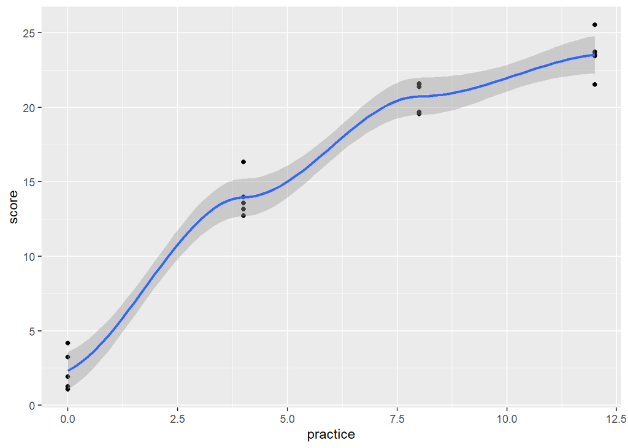

```r
ggplot(cog, aes(x = practice, y = score)) +
  geom_point() +
  geom_smooth(method = "loess")
```

What type of relationship do you think exists if any?

The slope appears to become less steep as length of assigned practice time increases. Since there may be a curve to the regression line, we should test for more than a linear effect. Since we have four levels of our categorical variable, we can test both a quadratic and cubic effect.

## Specify orthoganol polynomial contrast terms

```r
# these are common coefficients to specify for polynomial contrasts and these can be found online or in our demo slides. Note that we could use different contrasts for each type of relationship (e.g., linear, quadratic, etc.) if the categorical predictor had a different number of levels.
# Also note that we could not evaluate a cubic effect if we had <4 levels of the categorical predictor.

cog <- mutate(cog,

              linear = ifelse(practice == 0, -3, practice ),
              linear = ifelse(practice == 4, -1, linear   ),
              linear = ifelse(practice == 8,  1, linear   ),
              linear = ifelse(practice == 12, 3, linear   ),

              quadratic = ifelse(practice == 0,  1, practice ),
              quadratic = ifelse(practice == 4, -1, quadratic),
              quadratic = ifelse(practice == 8, -1, quadratic),
              quadratic = ifelse(practice == 12, 1, quadratic),

              cubic = ifelse(practice == 0, -1, practice),
              cubic = ifelse(practice == 4,  3, cubic   ),
              cubic = ifelse(practice == 8, -3, cubic   ),
              cubic = ifelse(practice == 12, 1, cubic   )
              )
```

## Run model with just the linear effect

```r
m3 <- lm(score ~ linear, data = cog)
ols_regress(m3)
```

```
##                         Model Summary
## --------------------------------------------------------------
## R                       0.953       RMSE                2.635
## R-Squared               0.909       Coef. Var          17.400
## Adj. R-Squared          0.903       MSE                 6.943
## Pred R-Squared          0.886       MAE                 2.207
## --------------------------------------------------------------
##  RMSE: Root Mean Square Error
##  MSE: Mean Square Error
##  MAE: Mean Absolute Error
##
##                                 ANOVA
## ---------------------------------------------------------------------
##                 Sum of
##                Squares        DF    Mean Square       F         Sig.
## ---------------------------------------------------------------------
## Regression    1240.975         1       1240.975    178.727    0.0000
## Residual       124.981        18          6.943
## Total         1365.957        19
## ---------------------------------------------------------------------
##
##                                   Parameter Estimates
## ----------------------------------------------------------------------------------------
##       model      Beta    Std. Error    Std. Beta      t        Sig      lower     upper
## ----------------------------------------------------------------------------------------
## (Intercept)    15.144         0.589                 25.702    0.000    13.906    16.382
##      linear     3.523         0.264        0.953    13.369    0.000     2.969     4.076
## ----------------------------------------------------------------------------------------
```

These are the results of the liner model. The model testing the linear relationship between practice and score explained 90.9% of the variance in score, and the linear trend was statistically significant at p<0.001. This model fits the data pretty well, but since we observed a potential curved relationship when we plotted the data, there could be a better way to examine this relationship.

## Run model with the linear and quadratic effects

```r
m4 <- lm(score ~ linear + quadratic, data = cog)
ols_regress(m4)
```

```
##                         Model Summary
## -------------------------------------------------------------
## R                       0.990       RMSE               1.274
## R-Squared               0.980       Coef. Var          8.411
## Adj. R-Squared          0.977       MSE                1.623
## Pred R-Squared          0.972       MAE                0.944
## -------------------------------------------------------------
##  RMSE: Root Mean Square Error
##  MSE: Mean Square Error
##  MAE: Mean Absolute Error
##
##                                 ANOVA
## ---------------------------------------------------------------------
##                 Sum of
##                Squares        DF    Mean Square       F         Sig.
## ---------------------------------------------------------------------
## Regression    1338.373         2        669.187    412.425    0.0000
## Residual        27.584        17          1.623
## Total         1365.957        19
## ---------------------------------------------------------------------
##
##                                   Parameter Estimates
## ----------------------------------------------------------------------------------------
##       model      Beta    Std. Error    Std. Beta      t        Sig      lower     upper
## ----------------------------------------------------------------------------------------
## (Intercept)    15.144         0.285                 53.168    0.000    14.543    15.745
##      linear     3.523         0.127        0.953    27.655    0.000     3.254     3.791
##   quadratic    -2.207         0.285       -0.267    -7.748    0.000    -2.808    -1.606
## ----------------------------------------------------------------------------------------
```

These are the results of the quadratic model. The model testing the linear relationship between practice and score explained 98.0% of the variance in score, which is 7.1% higher than the model that only tested the linear relationship. The quadratic term (named quadratic) is statistically significant, indicating that there is a substantial curve to the relationship between practice and score (i.e., it’s not linear). We need to maintain the quadratic term in the model.

## Run model with the linear, quadratic, and cubic effects

```r
m5 <- lm(score ~ linear + quadratic + cubic, data = cog)
ols_regress(m5)
```

```
##                         Model Summary
## -------------------------------------------------------------
## R                       0.990       RMSE               1.309
## R-Squared               0.980       Coef. Var          8.641
## Adj. R-Squared          0.976       MSE                1.712
## Pred R-Squared          0.969       MAE                0.954
## -------------------------------------------------------------
##  RMSE: Root Mean Square Error
##  MSE: Mean Square Error
##  MAE: Mean Absolute Error
##
##                                 ANOVA
## ---------------------------------------------------------------------
##                 Sum of
##                Squares        DF    Mean Square       F         Sig.
## ---------------------------------------------------------------------
## Regression    1338.559         3        446.186    260.572    0.0000
## Residual        27.397        16          1.712
## Total         1365.957        19
## ---------------------------------------------------------------------
##
##                                   Parameter Estimates
## ----------------------------------------------------------------------------------------
##       model      Beta    Std. Error    Std. Beta      t        Sig      lower     upper
## ----------------------------------------------------------------------------------------
## (Intercept)    15.144         0.293                 51.755    0.000    14.524    15.764
##      linear     3.523         0.131        0.953    26.921    0.000     3.245     3.800
##   quadratic    -2.207         0.293       -0.267    -7.542    0.000    -2.827    -1.586
##       cubic     0.043         0.131        0.012     0.330    0.746    -0.234     0.321
## ----------------------------------------------------------------------------------------
```

# Do it yourself activity

## Load packages

```r
library(tsibble)
library(tidycovid19)
```

## Download data

```r
covid <- download_merged_data(cached = TRUE)
```

## Recode lockdown variable

```r
covid <- mutate(covid, lockdown = ifelse(lockdown > 0, 1, lockdown))
```

## Dummy code/factor income & lockdown

```r
covid <- mutate(covid,

               lowmid = ifelse(income == "Lower middle income", 1, 0),
               upmid  = ifelse(income == "Upper middle income", 1, 0),
               high   = ifelse(income == "High income"        , 1, 0),

               income = factor(income,
                                levels = c("Low income", "Lower middle income", "Upper middle income", "High income"),
                                labels = c(1,2,3,4)),

               income = factor(income,
                                labels = c("Low income", "Lower middle income", "Upper middle income", "High income"),
                                levels = c(1,2,3,4))
                                )
```

## Describe data

```r
covid %>%
  select_if(is.numeric) %>%
  describe()
```

|  | vars | n | mean | sd | median | trimmed | mad | min | max | range | skew | kurtosis | se |
| --- | --- | --- | --- | --- | --- | --- | --- | --- | --- | --- | --- | --- | --- |
| confirmed | 1 | 20240 | 5.472157e+03 | 4.254385e+04 | 9.00000 | 2.989817e+02 | 1.334340e+01 | 0.000000e+00 | 1.329260e+06 | 1.329260e+06 | 19.82884988 | 488.39495890 | 2.990415e+02 |
| deaths | 2 | 20240 | 3.627870e+02 | 2.945705e+03 | 0.00000 | 6.310894e+00 | 0.000000e+00 | 0.000000e+00 | 7.952600e+04 | 7.952600e+04 | 14.61973341 | 274.55403406 | 2.070542e+01 |
| recovered | 3 | 20240 | 1.563100e+03 | 1.013249e+04 | 0.00000 | 4.421060e+01 | 0.000000e+00 | 0.000000e+00 | 2.161690e+05 | 2.161690e+05 | 10.15438215 | 126.49842038 | 7.122148e+01 |
| ecdc_cases | 4 | 13561 | 8.081318e+03 | 5.155970e+04 | 122.00000 | 8.608302e+02 | 1.779120e+02 | 1.000000e+00 | 1.329799e+06 | 1.329798e+06 | 16.46324370 | 333.91961530 | 4.427561e+02 |
| ecdc_deaths | 5 | 13561 | 5.361588e+02 | 3.564878e+03 | 2.00000 | 2.008821e+01 | 2.965200e+00 | 0.000000e+00 | 7.952800e+04 | 7.952800e+04 | 12.05467282 | 186.59422483 | 3.061250e+01 |
| total_tests | 6 | 4171 | 1.704072e+05 | 5.846842e+05 | 31134.00000 | 6.021379e+04 | 4.399171e+04 | 1.000000e+00 | 8.709630e+06 | 8.709629e+06 | 8.24984850 | 83.71219692 | 9.053183e+03 |
| soc_dist | 7 | 19910 | 2.768307e+00 | 3.855548e+00 | 1.00000 | 2.055186e+00 | 1.482600e+00 | -1.100000e+01 | 3.500000e+01 | 4.600000e+01 | 2.14276408 | 8.43602859 | 2.732439e-02 |
| mov_rest | 8 | 19910 | 4.073380e+00 | 5.735833e+00 | 2.00000 | 2.937406e+00 | 2.965200e+00 | 0.000000e+00 | 5.100000e+01 | 5.100000e+01 | 2.45895957 | 9.41171093 | 4.065003e-02 |
| pub_health | 9 | 19910 | 6.263536e+00 | 1.060834e+01 | 3.00000 | 3.977838e+00 | 4.447800e+00 | 0.000000e+00 | 1.180000e+02 | 1.180000e+02 | 4.17425757 | 27.34158338 | 7.518167e-02 |
| gov_soc_econ | 10 | 19910 | 3.401457e+00 | 6.680214e+00 | 1.00000 | 1.828101e+00 | 1.482600e+00 | -1.000000e+00 | 6.600000e+01 | 6.700000e+01 | 3.74291495 | 19.34081962 | 4.734288e-02 |

[output cut: 21 more lines]

```r
table(covid$income)
```

```
##
##          Low income Lower middle income Upper middle income         High income
##                3330                4662                5803                7234
```

```r
table(covid$lockdown)
```

```
##
##    -3    -2    -1     0     1
##     8     2    45 14292  5563
```

## Run dummy model

```r
cov_dum <- lm(confirmed ~  lockdown + lowmid + upmid + high + lockdown*lowmid + lockdown*upmid + lockdown*high,
              data = covid)
ols_regress(cov_dum)
```

```
##                             Model Summary
## ----------------------------------------------------------------------
## R                       0.160       RMSE                    42575.224
## R-Squared               0.026       Coef. Var                 757.266
## Adj. R-Squared          0.025       MSE                1812649703.051
## Pred R-Squared          0.025       MAE                      8733.648
## ----------------------------------------------------------------------
##  RMSE: Root Mean Square Error
##  MSE: Mean Square Error
##  MAE: Mean Absolute Error
##
##                                        ANOVA
## ------------------------------------------------------------------------------------
##                         Sum of
##                        Squares           DF         Mean Square      F         Sig.
## ------------------------------------------------------------------------------------
## Regression    939255191603.328            7    134179313086.190    74.024    0.0000
## Residual          3.567657e+13        19682      1812649703.051
## Total             3.661583e+13        19689
## ------------------------------------------------------------------------------------
##
##                                          Parameter Estimates
## -----------------------------------------------------------------------------------------------------
##           model         Beta    Std. Error    Std. Beta      t        Sig         lower        upper
## -----------------------------------------------------------------------------------------------------
##     (Intercept)       52.624       812.330                  0.065    0.948    -1539.612     1644.861
##        lockdown      145.458      1963.204        0.072     0.074    0.941    -3702.587     3993.504
##          lowmid      697.896      1074.999        0.006     0.649    0.516    -1409.192     2804.984
##           upmid     2305.667      1067.656        0.041     2.160    0.031      212.971     4398.363
##            high     9093.618      1040.153        0.142     8.743    0.000     7054.831    11132.405
## lockdown:lowmid     -195.375      2392.770       -0.001    -0.082    0.935    -4885.407     4494.658
##  lockdown:upmid     5599.896      2283.435        0.028     2.452    0.014     1124.171    10075.622
##   lockdown:high    15140.996      2304.139        0.074     6.571    0.000    10624.689    19657.302
## -----------------------------------------------------------------------------------------------------
```

## Effect coding variables

```r
covid <- mutate(covid,

               lowmid = ifelse(income == "Lower middle income", 1, 0),
               upmid  = ifelse(income == "Upper middle income", 1, 0),
               high   = ifelse(income == "High income"        , 1, 0),

              lowmid = ifelse(income == "Low income", (-1), lowmid),
              upmid  = ifelse(income == "Low income", (-1), upmid ),
              high   = ifelse(income == "Low income", (-1), high  )
              )
```

## Run effect model

```r
cov_eff <- lm(confirmed ~  lockdown + lowmid + upmid + high + lockdown*lowmid + lockdown*upmid + lockdown*high,
              data = covid)
ols_regress(cov_eff)
```

```
##                             Model Summary
## ----------------------------------------------------------------------
## R                       0.160       RMSE                    42575.224
## R-Squared               0.026       Coef. Var                 757.266
## Adj. R-Squared          0.025       MSE                1812649703.051
## Pred R-Squared          0.025       MAE                      8733.648
## ----------------------------------------------------------------------
##  RMSE: Root Mean Square Error
##  MSE: Mean Square Error
##  MAE: Mean Absolute Error
##
##                                        ANOVA
## ------------------------------------------------------------------------------------
##                         Sum of
##                        Squares           DF         Mean Square      F         Sig.
## ------------------------------------------------------------------------------------
## Regression    939255191603.203            7    134179313086.172    74.024    0.0000
## Residual          3.567657e+13        19682      1812649703.051
## Total             3.661583e+13        19689
## ------------------------------------------------------------------------------------
##
##                                          Parameter Estimates
## -----------------------------------------------------------------------------------------------------
##           model         Beta    Std. Error    Std. Beta      t        Sig         lower        upper
## -----------------------------------------------------------------------------------------------------
##     (Intercept)     3076.920       358.614                  8.580    0.000     2374.005     3779.834
##        lockdown     5281.838       730.588        0.072     7.230    0.000     3849.823     6713.852
##          lowmid    -2326.399       613.576       -0.056    -3.792    0.000    -3529.059    -1123.739
##           upmid     -718.628       607.131       -0.009    -1.184    0.237    -1908.657      471.401
##            high     6069.323       582.772        0.138    10.415    0.000     4927.041     7211.604
## lockdown:lowmid    -5331.754      1212.167       -0.033    -4.399    0.000    -7707.704    -2955.804
##  lockdown:upmid      463.517      1101.686        0.003     0.421    0.674    -1695.881     2622.914
##   lockdown:high    10004.616      1123.032        0.066     8.909    0.000     7803.378    12205.855
## -----------------------------------------------------------------------------------------------------
```

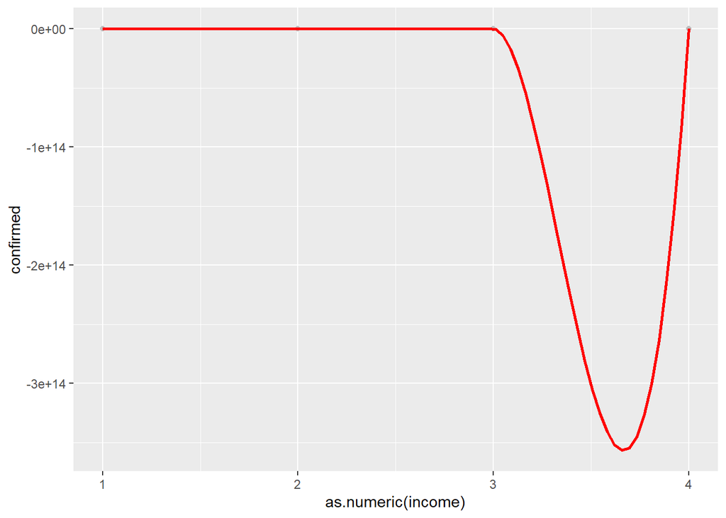

```r
ggplot(covid, aes(x = as.numeric(income), y = confirmed)) +
  geom_point(color = "grey") +
  geom_smooth(method = "loess", se = FALSE, color = "red")
```

## Orthoganol polynomials

```r
covid <- mutate(covid,

              linear = ifelse(income == "Low income"         , -3, income ),
              linear = ifelse(income == "Lower middle income", -1, linear   ),
              linear = ifelse(income == "Upper middle income",  1, linear   ),
              linear = ifelse(income == "High income"        ,  3, linear   ),

              quadratic = ifelse(income == "Low income"         ,  1, income ),
              quadratic = ifelse(income == "Lower middle income", -1, quadratic),
              quadratic = ifelse(income == "Upper middle income", -1, quadratic),
              quadratic = ifelse(income == "High income"        ,  1, quadratic),

              cubic = ifelse(income == "Low income"         , -1, income),
              cubic = ifelse(income == "Lower middle income",  3, cubic   ),
              cubic = ifelse(income == "Upper middle income", -3, cubic   ),
              cubic = ifelse(income == "High income"        ,  1, cubic   )
              )
```

```r
cov_linear <- lm(confirmed ~ linear, data = covid)
ols_regress(cov_linear)
```

```
##                             Model Summary
## ----------------------------------------------------------------------
## R                       0.116       RMSE                    42602.595
## R-Squared               0.013       Coef. Var                 765.989
## Adj. R-Squared          0.013       MSE                1814981118.991
## Pred R-Squared          0.013       MAE                      9871.778
## ----------------------------------------------------------------------
##  RMSE: Root Mean Square Error
##  MSE: Mean Square Error
##  MAE: Mean Absolute Error
##
##                                         ANOVA
## -------------------------------------------------------------------------------------
##                         Sum of
##                        Squares           DF         Mean Square       F         Sig.
## -------------------------------------------------------------------------------------
## Regression    489707601462.477            1    489707601462.477    269.814    0.0000
## Residual          3.613264e+13        19908      1814981118.991
## Total             3.662235e+13        19909
## -------------------------------------------------------------------------------------
##
##                                      Parameter Estimates
## ----------------------------------------------------------------------------------------------
##       model        Beta    Std. Error    Std. Beta      t        Sig        lower       upper
## ----------------------------------------------------------------------------------------------
## (Intercept)    4398.271       310.124                 14.182    0.000    3790.403    5006.139
##      linear    2314.230       140.888        0.116    16.426    0.000    2038.078    2590.383
## ----------------------------------------------------------------------------------------------
```

```r
cov_quadratic <- lm(confirmed ~ linear + quadratic, data = covid)
ols_regress(cov_quadratic)
```

```
##                             Model Summary
## ----------------------------------------------------------------------
## R                       0.125       RMSE                    42555.644
## R-Squared               0.016       Coef. Var                 765.144
## Adj. R-Squared          0.015       MSE                1810982818.472
## Pred R-Squared          0.015       MAE                      9081.882
## ----------------------------------------------------------------------
##  RMSE: Root Mean Square Error
##  MSE: Mean Square Error
##  MAE: Mean Absolute Error
##
##                                         ANOVA
## -------------------------------------------------------------------------------------
##                         Sum of
##                        Squares           DF         Mean Square       F         Sig.
## -------------------------------------------------------------------------------------
## Regression    571116751002.141            2    285558375501.070    157.681    0.0000
## Residual          3.605123e+13        19907      1810982818.472
## Total             3.662235e+13        19909
## -------------------------------------------------------------------------------------
##
##                                      Parameter Estimates
## ----------------------------------------------------------------------------------------------
##       model        Beta    Std. Error    Std. Beta      t        Sig        lower       upper
## ----------------------------------------------------------------------------------------------
## (Intercept)    4570.961       310.851                 14.705    0.000    3961.667    5180.254
##      linear    2129.371       143.408        0.106    14.848    0.000    1848.279    2410.463
##   quadratic    2062.076       307.557        0.048     6.705    0.000    1459.239    2664.913
## ----------------------------------------------------------------------------------------------
```

```r
cov_cubic <- lm(confirmed ~ linear + quadratic + cubic, data = covid)
ols_regress(cov_cubic)
```

```
##                             Model Summary
## ----------------------------------------------------------------------
## R                       0.125       RMSE                    42555.993
## R-Squared               0.016       Coef. Var                 765.151
## Adj. R-Squared          0.015       MSE                1811012528.146
## Pred R-Squared          0.015       MAE                      9073.583
## ----------------------------------------------------------------------
##  RMSE: Root Mean Square Error
##  MSE: Mean Square Error
##  MAE: Mean Absolute Error
##
##                                         ANOVA
## -------------------------------------------------------------------------------------
##                         Sum of
##                        Squares           DF         Mean Square       F         Sig.
## -------------------------------------------------------------------------------------
## Regression    572336333057.320            3    190778777685.773    105.344    0.0000
## Residual          3.605002e+13        19906      1811012528.146
## Total             3.662235e+13        19909
## -------------------------------------------------------------------------------------
##
##                                      Parameter Estimates
## ----------------------------------------------------------------------------------------------
##       model        Beta    Std. Error    Std. Beta      t        Sig        lower       upper
## ----------------------------------------------------------------------------------------------
## (Intercept)    4568.379       310.869                 14.696    0.000    3959.049    5177.708
##      linear    2135.283       143.590        0.107    14.871    0.000    1853.834    2416.732
##   quadratic    2024.949       310.869        0.047     6.514    0.000    1415.620    2634.278
##       cubic     110.214       134.304        0.006     0.821    0.412    -153.034     373.461
## ----------------------------------------------------------------------------------------------
```